# Análisis del crimen en L.A. con H2O

## Cambio de nombre de las variables

Vemos los nombres

```r
names(crime_data)
```

```
##  [1] "DR.Number"              "Date.Reported"
##  [3] "Date.Occurred"          "Time.Occurred"
##  [5] "Area.ID"                "Area.Name"
##  [7] "Reporting.District"     "Crime.Code"
##  [9] "Crime.Code.Description" "MO.Codes"
## [11] "Victim.Age"             "Victim.Sex"
## [13] "Victim.Descent"         "Premise.Code"
## [15] "Premise.Description"    "Weapon.Used.Code"
## [17] "Weapon.Description"     "Status.Code"
## [19] "Status.Description"     "Crime.Code.1"
## [21] "Crime.Code.2"           "Crime.Code.3"
## [23] "Crime.Code.4"           "Address"
## [25] "Cross.Street"           "Location"
```

Vamos a cambiarlas

```r
# Minusculas
names(crime_data) <- tolower(names(crime_data))

# cambiar . por _
names(crime_data) <- gsub('.', '_', names(crime_data), fixed = TRUE)

# Las vemos
names(crime_data)
```

```
##  [1] "dr_number"              "date_reported"
##  [3] "date_occurred"          "time_occurred"
##  [5] "area_id"                "area_name"
##  [7] "reporting_district"     "crime_code"
##  [9] "crime_code_description" "mo_codes"
## [11] "victim_age"             "victim_sex"
## [13] "victim_descent"         "premise_code"
## [15] "premise_description"    "weapon_used_code"
## [17] "weapon_description"     "status_code"
## [19] "status_description"     "crime_code_1"
## [21] "crime_code_2"           "crime_code_3"
## [23] "crime_code_4"           "address"
## [25] "cross_street"           "location"
```

## Análisis de NAs

Algunos cambios en valores para pasarlos a NA

### Mo Codes

```r
# Los pasamos a caracter
crime_data$mo_codes <- as.character(crime_data$mo_codes)

# Cambiamos los valores en blanco por NA
crime_data$mo_codes[crime_data$mo_codes==''] <- NA

# table(crime_data$mo_code, useNA = 'ifany') # Ocupa mucho
```

Creamos un objeto con los valores únicos

```r
# Los valores únicos de crime_data$mo_codes
mo_codes <- unique(as.character(crime_data$mo_codes))

# Quitamos los NAs
mo_codes <- mo_codes[!is.na(mo_codes)]
```

```r
# Sacamos los valores únicos
mo_codes_unique <- unique(paste(mo_codes, collapse = ' '))

# Separamos los valores con ' '
mo_codes <- unique(strsplit(mo_codes_unique, ' '))

# Pasamos a character
mo_codes <- unlist(mo_codes)

# Nos quedamos con los valores únicos
mo_codes <- unique(mo_codes)

# Los ordenamos
mo_codes <- mo_codes[order(mo_codes)]

# Cuantos hay
length(mo_codes)
```

```
## [1] 679
```

Aquí podríamos obtener un one-hot-encoding de los mo_codes. No lo hacemos porque estamos evaluando la eficacia de autoML, pero es uno de los temas a tratar para mejorar el modelado

### Status codes

```r
# Los pasamos a caracter
crime_data$status_code <- as.character(crime_data$status_code)

# Cambiamos los valores en blanco por NA
crime_data$status_code[crime_data$status_code==''] <- NA

# Volvemos a pasar a factor
crime_data$status_code <- as.factor(crime_data$status_code)

# Sacamos una tabla
table(crime_data$status_code, useNA = 'ifany')
```

```
##
##      13      19      AA      AO      CC      IC      JA      JO      TH
##       1       1  177681  196597      26 1339811   13593    4324       1
##    <NA>
##       2
```

### Cross Street

```r
# Pasamos a caracter
crime_data$cross_street <- as.character(crime_data$cross_street)

# Cambiamos los valores en blanco por NA
crime_data$cross_street[crime_data$cross_street %in% c('')] <- NA

# table(crime_data$cross_street, useNA = 'ifany')  # Muy largo

# Volvemos a pasar a factor
crime_data$cross_street <- as.factor(crime_data$cross_street)
```

### Weapon description

```r
# Pasamos a caracter
crime_data$weapon_description <- as.character(crime_data$weapon_description)

# Cambiamos los valores en blanco por NA
crime_data$weapon_description[crime_data$weapon_description %in% c('')] <- NA

# table(crime_data$weapon_description, useNA = 'ifany')  # Muy largo

# Volvemos a pasar a factor
crime_data$weapon_description <- as.factor(crime_data$weapon_description)
```

### Crime code description

```r
crime_data$crime_code_description <- as.character(crime_data$crime_code_description)


crime_data$crime_code_description[crime_data$crime_code_description %in% c('')] <- NA

# table(crime_data$crime_code_description, useNA = 'ifany')

# Volvemos a pasar a factor
crime_data$crime_code_description <- as.factor(crime_data$cross_street)
```

### Premise description

```r
# Pasamos a caracter
crime_data$premise_description <- as.character(crime_data$premise_description)

# Cambiamos los valores en blanco por NA
crime_data$premise_description[crime_data$premise_description %in% c('')] <- NA

# table(crime_data$premise_description, useNA = 'ifany')

# Volvemos a pasar a factor
crime_data$premise_description <- as.factor(crime_data$premise_description)
```

### Address

```r
# Pasamos a caracter
crime_data$address <- as.character(crime_data$address)

# Cambiamos los valores '00' por NA
crime_data$address[crime_data$address=='00'] <- NA

# table(crime_data$address, useNA = 'ifany')

# Pasamos a factor
crime_data$address <- as.factor(crime_data$address)
```

### Sex

```r
# Pasamos a caracter
crime_data$victim_sex <- as.character(crime_data$victim_sex)

# Cambiamos los valores en blanco y los '-' por NA
crime_data$victim_sex[crime_data$victim_sex %in% c('', '-')] <- NA

# Una tabla
table(crime_data$victim_sex, useNA = 'ifany')
```

```
##
##      F      H      M      X   <NA>
## 735603     57 805774  30852 159751
```

```r
# Volvemos a pasar a factor
crime_data$victim_sex <- as.factor(crime_data$victim_sex)
```

### Descent Code

A - Other Asian B - Black C - Chinese D - Cambodian F - Filipino G - Guamanian H - Hispanic/Latin/Mexican I - American Indian/Alaskan Native J - Japanese K - Korean L - Laotian O - Other P - Pacific Islander S - Samoan U - Hawaiian V - Vietnamese W - White X - Unknown Z - Asian Indian

```r
# Renombramos los niveles
levels(crime_data$victim_descent) <- c("", "-", " Other_Asian", "Black",
                                       "Chinese", "Cambodian", "Filipino",
                                       "Guamanian", "Hispanic-Latin-Mexican",
                                       "American_Indian-Alaskan_Native",
                                       "Japanese", "Korean", "Laotian", "Other",
                                       "Pacific_Islander", "Samoan",
                                       "Hawaiian", "Vietnamese", "White",
                                       "Unknown", "Asian_Indian")
# Pasamos a caracter
crime_data$victim_descent <- as.character(crime_data$victim_descent)

# Cambiamos los valores en blanco y los '-' por 'Unknown'
crime_data$victim_descent[crime_data$victim_descent %in% c('', '-')] <- 'Unknown'

# Una tabla
table(crime_data$victim_descent, useNA = 'ifany')
```

```
##
## American_Indian-Alaskan_Native                   Asian_Indian
##                            731                             62
##                          Black                      Cambodian
##                         277089                             16
##                        Chinese                       Filipino
##                            653                           2028
##                      Guamanian                       Hawaiian
##                             71                            159
##         Hispanic-Latin-Mexican                       Japanese
##                         598962                            253
##                         Korean                        Laotian
##                           7735                             11
##                          Other                    Other_Asian
##                         167496                          40955
##               Pacific_Islander                         Samoan
##                            304                             26
##                        Unknown                     Vietnamese
##                         209715                             93
##                          White
##                         425678
```

```r
# Y volvemos a factor
crime_data$victim_descent <- as.factor(crime_data$victim_descent)
```

### Location

```r
# pasamos a caracter
crime_data$location <- as.character(crime_data$location)

# Los que tienen location '' los pasamos a '(0, 0)'
crime_data$location[crime_data$location==""] <- "(0, 0)"

# table(crime_data$location, useNA = 'ifany')
```

Creamos un objeto (crime_data_location) y limpiamos crime_data_location, quitando ‘’, ‘(’ y ‘)’

```r
# Copiamos de crime_data$location
crime_data_location <- crime_data$location

# Quitamos los '('
crime_data_location <- gsub('(', '', crime_data_location, fixed = TRUE)

# Quitamos los ')'
crime_data_location <- gsub(')', '', crime_data_location, fixed = TRUE)

# Quitamos los ' '
crime_data_location <- gsub(' ', '', crime_data_location, fixed = TRUE)
```

```r
temp2 <- strsplit(crime_data_location, ',')
# temp3 <- as.data.frame(temp2)
temp4 <- unlist(temp2)
temp5 <- stringr::str_split(crime_data_location, ',')
# temp6 <- as.data.frame(temp5, optional = TRUE)

# https://stackoverflow.com/questions/4227223/r-list-to-data-frame
temp7 <- do.call(rbind.data.frame, temp2)
# temp8 <- do.call(rbind, lapply(temp2, data.frame, stringsAsFactors=FALSE))
# temp9 <- do.call(rbind, lapply(temp2, matrix, stringsAsFactors=FALSE))
temp10 <- data.frame(matrix(unlist(temp2), nrow=1674208, byrow=T),
                     stringsAsFactors=FALSE)
```

Vamos a incluir en **crime_data** las variables location_x y location_y

```r
# https://stackoverflow.com/questions/4227223/r-list-to-data-frame
crime_data_location_df <- data.frame(matrix(unlist(strsplit(crime_data_location, ',')),
                                            nrow=length(crime_data_location),
                                            byrow=T), stringsAsFactors=FALSE)

# Cambiamos los nombres
names(crime_data_location_df) <- c('location_x', 'location_y')

# Pasamos a numérico
crime_data$location_x <- as.numeric(crime_data_location_df$location_x)
crime_data$location_y <- as.numeric(crime_data_location_df$location_y)

# Cambiamos los 0 por NAs
crime_data$location_x[crime_data$location_x==0] <- NA
crime_data$location_y[crime_data$location_y==0] <- NA

# Cambiamos también los (0, 0) por NAs
crime_data$location[crime_data$location=="(0, 0)"] <- NA

# Y pasamos location a factor (ya tenemos un location_x y location_y numericos)
crime_data$location <- as.factor(crime_data$location)
```

Limpiamos el entorno

```r
# Borramos dos datasets
rm(crime_data_location_df, crime_data_location)

# Limpiamos y vemos la memoria
gc()
```

```
##            used  (Mb) gc trigger  (Mb) max used  (Mb)
## Ncells  1349359  72.1    4703850 251.3  3485914 186.2
## Vcells 32127061 245.2   95422707 728.1 95390253 727.8
```

Creamos un contador de NAs para cada columna

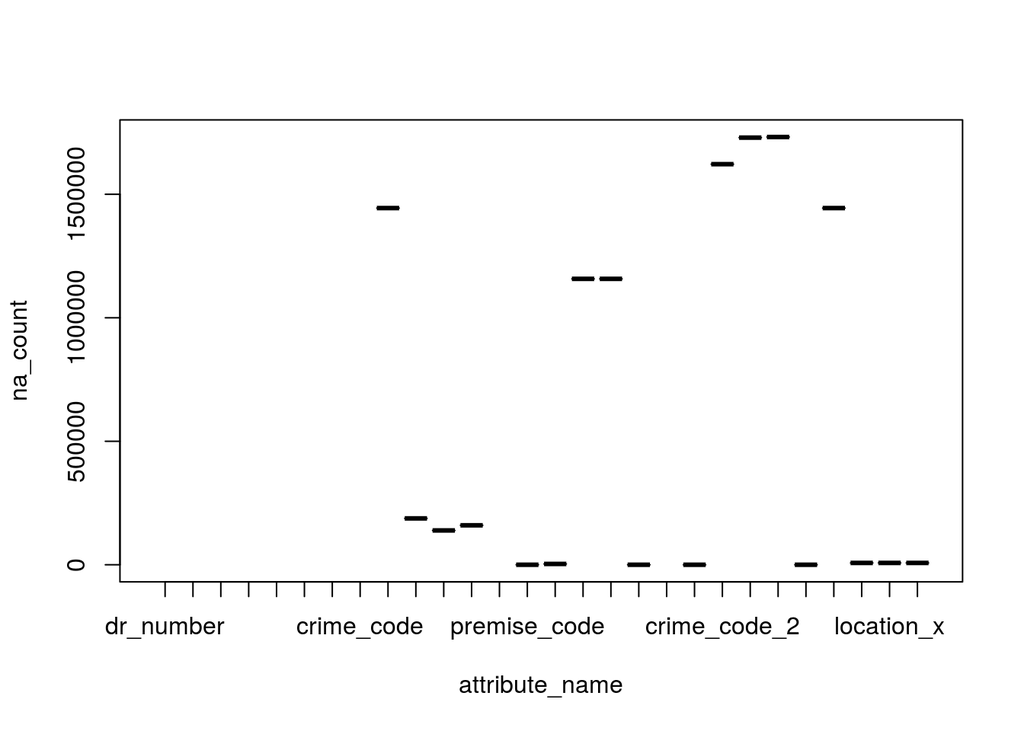

```r
# Creamos la nueva variable con un count
na_count <- do.call(rbind, lapply(colnames(crime_data), function(x) {return(data.frame(x, sum(is.na(crime_data[[x]]))))}))

# Cambiamos el nombre de las variables en el dataset
colnames(na_count) <- c('attribute_name', 'na_count')
# na_count$attribute_name <- as.character(na_count$attribute_name)

# Nos quedamos con los distintos de cero
na_count <- na_count[na_count$na_count != 0,]

# Lo vemos en gráfico
plot(na_count)
```

## Nuevas variables

```r
# Creamos una variable con el mes del crimen
crime_data$crime_month <- as.factor(substr(as.character(crime_data$date_occurred), 1, 2))

# Vemos en tabla
table(crime_data$crime_month, useNA = 'ifany')
```

```
##
##     01     02     03     04     05     06     07     08     09     10
## 162049 140575 156894 149682 141442 139198 143800 144159 138609 144086
##     11     12
## 133212 138331
```

Cambiamos los valores tipo fecha a formato as.Date

```r
crime_data$date_reported <- as.Date(as.character(crime_data$date_reported), '%m/%d/%Y')
crime_data$date_occurred <- as.Date(as.character(crime_data$date_occurred), '%m/%d/%Y')
```

Ordenamos por fecha

```r
crime_data <- crime_data[order(crime_data$date_occurred), ]
```

Generamos algunas columnas

Año

```r
# Con lubridate
# crime_data$crime_year  <- year(crime_data$date_occurred)
crime_data$crime_year  <- as.factor(substr(as.character(crime_data$date_occurred), 1, 4))
table(crime_data$crime_year, useNA = 'ifany')
```

```
##
##   2010   2011   2012   2013   2014   2015   2016   2017   2018
## 208661 200293 200937 191939 194700 214338 223955 229499  67715
```

Mes

```r
# Mes
# Con lubridate
# crime_data$crime_month <- month(crime_data$date_occurred, label = TRUE)
crime_data$crime_month <- as.factor(substr(as.character(crime_data$date_occurred), 6, 7))
table(crime_data$crime_month, useNA = 'ifany')
```

```
##
##     01     02     03     04     05     06     07     08     09     10
## 162049 140575 156894 149682 141442 139198 143800 144159 138609 144086
##     11     12
## 133212 138331
```

Semana

```r
crime_data$crime_week  <- week(crime_data$date_occurred)
table(crime_data$crime_week, useNA = 'ifany')
```

[output not shown]

Convertimos el tiempo con el paquete **chron**

```r
crime_data$crime_time  <- times(substr(as.POSIXct(sprintf("%04.0f", crime_data$time_occurred), origin = '1970-01-01', "Asia/Calcutta", format='%H%M'), 12, 19))
```

Creamos una variable minuto

```r
crime_data$crime_minute  <- (crime_data$time_occurred %/% 100)*60 + (crime_data$time_occurred %% 100)*100
table(crime_data$crime_minute, useNA = 'ifany')
```

```
##
##    60   100   120   160   180   200   220   240   260   280   300   320
## 21250 29934 18294    17 13455    77    16  9294    29    22  8148    19
##   340   360   380   400   420   440   460   480   500   520   540   560
##    10 13241    27    54 17582    29    37 42362  9243    45 32343   828
##   580   600   620   640   660   680   700   720   740   760   780   800
##    38 35697   806    41 28791   611    94 96068   500    78 31657   447
##   820   840   860   880   900   920   940   960   980  1000  1020  1040
##   167 35821   437    74 40565   573    80 40589   781  3444 45373   817
##  1060  1080  1100  1120  1140  1160  1180  1200  1220  1240  1260  1280
##  1894 51601  1018  1620 45891  1124  1246 48335  1395   987 44294  1253
##  1300  1320  1340  1360  1380  1400  1420  1440  1460  1480  1500  1520
##   910 45373  1386   835 35841  1404  1334   131  1383  1693  3844  1354
##  1540  1560  1580  1600  1620  1640  1660  1680  1700  1720  1740  1760
##  1678  2658  1400  1777  2488  1348  2123  1886  1506  2525  1420  1385
```

[output cut: 46 more lines]

Establecemos algunas franjas horarias

```r
crime_data$crime_time_interval  <- cut(crime_data$crime_time, breaks = times(c('00:00:00', '05:00:00', '09:00:00', '13:00:00', '17:00:00', '21:00:00', '23:59:00')), labels = c('Late_night', 'Early_morning', 'Late_morning', 'Early_afternoon', 'Late_afternoon', 'Evening'), include.lowest = TRUE)
table(crime_data$crime_time_interval, useNA = 'ifany')
```

```
##
##      Late_night   Early_morning    Late_morning Early_afternoon
##          224864          192430          346274          350930
##  Late_afternoon         Evening
##          397296          220243
```

```r
# crime_data$crime_time <- as.factor(crime_data$crime_time)
crime_data$crime_time <- NULL
```

Día de la semana

```r
crime_data$occurred_week_day <- factor(weekdays(crime_data$date_occurred),
                                       levels = c("lunes", "martes",
                                                  "miércoles", "jueves",
                                                  "viernes", "sábado",
                                                  "domingo"))
table(crime_data$occurred_week_day, useNA = 'ifany')
```

```
##
##     lunes    martes miércoles    jueves   viernes    sábado   domingo
##    246857    242741    245339    243598    267042    248884    237576
```

Tiempo de retraso a la hora de denunciar

```r
crime_data$delay_reported <- crime_data$date_reported - crime_data$date_occurred
crime_data$delay_reported <- as.numeric(crime_data$delay_reported)
```

```r
# En esta parte se crean nuevas variables a partir de la suma y de la media
# No se ejecuta al tener eval=FALSE
week_day_occurred_sum   <- aggregate(date_occurred ~ occurred_week_day,
                                     data = crime_data, "sum")
week_day_occurred_mean  <- aggregate(date_occurred ~ occured_week_day,
                                     data = crime_data, "mean")

all_sum   <- aggregate(target ~ date_occurred + occurred_week_day,
                       data = train, "sum")
all_mean  <- aggregate(target ~ date_occurred + occured_week_day,
                       data = train, "mean")

plot(all_mean$date_occurred, all_mean$target)
```

Otro **summary()**

```r
summary(crime_data)
```

```
##    dr_number         date_reported        date_occurred
##  Min.   :      210   Min.   :2010-01-01   Min.   :2010-01-01
##  1st Qu.:120415222   1st Qu.:2012-03-05   1st Qu.:2012-02-12
##  Median :140915418   Median :2014-05-29   Median :2014-05-07
##  Mean   :139242719   Mean   :2014-04-19   Mean   :2014-04-02
##  3rd Qu.:161015482   3rd Qu.:2016-06-11   3rd Qu.:2016-05-26
##  Max.   :910220366   Max.   :2018-04-28   Max.   :2018-04-28
##
##  time_occurred     area_id            area_name       reporting_district
##  Min.   :   1   Min.   : 1.00   77th Street: 120359   Min.   : 100
##  1st Qu.: 930   1st Qu.: 6.00   Southwest  : 111617   1st Qu.: 645
##  Median :1430   Median :12.00   N Hollywood:  94146   Median :1204
##  Mean   :1363   Mean   :11.14   Pacific    :  91557   Mean   :1160
##  3rd Qu.:1900   3rd Qu.:16.00   Southeast  :  91025   3rd Qu.:1675
##  Max.   :2359   Max.   :21.00   Mission    :  87061   Max.   :2198
##                                 (Other)    :1136272
##    crime_code                        crime_code_description
##  Min.   :110.0   BROADWAY                       :   5052
##  1st Qu.:330.0   FIGUEROA                       :   3044
##  Median :440.0   VERMONT                      AV:   3044
##  Mean   :506.9   SAN PEDRO                      :   2906
##  3rd Qu.:626.0   WESTERN                      AV:   2889
##  Max.   :956.0   (Other)                        : 270951
##                  NA's                           :1444151
##    mo_codes           victim_age     victim_sex
##  Length:1732037     Min.   :10.00    F   :735603
##  Class :character   1st Qu.:23.00    H   :    57
##  Mode  :character   Median :34.00    M   :805774
##                     Mean   :35.98    X   : 30852
##                     3rd Qu.:48.00    NA's:159751
##                     Max.   :99.00
##                     NA's   :138916
##                 victim_descent    premise_code
##  Hispanic-Latin-Mexican:598962   Min.   :101
##  White                 :425678   1st Qu.:102
##  Black                 :277089   Median :210
##  Unknown               :209715   Mean   :312
##  Other                 :167496   3rd Qu.:501
##   Other_Asian          : 40955   Max.   :971
##  (Other)               : 12142   NA's   :85
```

[output cut: 49 more lines]

```
##  Min.   :33.34   Min.   :-118.8   01     :162049   2017   :229499
##  1st Qu.:34.01   1st Qu.:-118.4   03     :156894   2016   :223955
##  Median :34.06   Median :-118.3   04     :149682   2015   :214338
##  Mean   :34.08   Mean   :-118.4   08     :144159   2010   :208661
##  3rd Qu.:34.18   3rd Qu.:-118.3   10     :144086   2012   :200937
##  Max.   :34.79   Max.   :-117.7   07     :143800   2011   :200293
##  NA's   :7488    NA's   :7488     (Other):831367   (Other):454354
##   crime_minute       crime_time_interval occurred_week_day  delay_reported
##  Min.   :  60   Late_night     :224864   lunes    :246857   Min.   :   0
##  1st Qu.: 840   Early_morning  :192430   martes   :242741   1st Qu.:   0
##  Median :1400   Late_morning   :346274   miércoles:245339   Median :   1
##  Mean   :2383   Early_afternoon:350930   jueves   :243598   Mean   :  17
##  3rd Qu.:3960   Late_afternoon :397296   viernes  :267042   3rd Qu.:   2
##  Max.   :7280   Evening        :220243   sábado   :248884   Max.   :3016
##                                          domingo  :237576
```